# Probabilistic Graphical Lasso

NIANG Mohamed

06 April 2020

# 1 Exercise 1: The elements of Statistical Learning

## 1.1 Choice of section to be read

For this part, we have chosen to read the section 17.3.2 entitled **Estimation of the Graph Structure**.

Given some realizations of $X$, we would like to estimate the parameters of an undirected graph that approximates their joint distribution. Suppose first that the graph is complete (fully connected). We assume that we have $N$ multivariate normal realizations $x_i$, $i = 1,... ,N$ with population mean $\mu$ and covariance $\Sigma$.

Let

$$\mathbf{S}=\frac{1}{N} \sum_{i=1}^{N}\left(x_{i}-\bar{x}\right)\left(x_{i}-\bar{x}\right)^{T}$$

be the empirical covariance matrix, with $\bar{x}$ the sample mean vector.

## 1.2 Summary of chosen section: Estimation of the Graph Structure

The **L1 (lasso) regularization** is a way to find out from the data which **edges** should be omitted from the graph. Meinshausen et al (2006) take a lasso regression approach using each variable as a response and the others as predictors to estimate which components of $\theta_{ij}$ are non-zero. The $\theta_{ij}$ component is then estimated as non-zero if the estimated coefficient of variable $i$ on $j$ is non-zero, or inversely. This procedure makes it possible to consistently estimate all non-zero components of $\Theta$.

It is possible to adopt a more systematic approach with the lasso penalty by maximizing the log-likelihood penalized

$$\log \operatorname{det} \Theta-\operatorname{trace}(\mathbf{S} \Theta)-\lambda\|\Theta\|_{1},$$

where $\|\Theta\|_{1}$ is the L1 norm - the sum of the absolute values of the elements of $\sum^{-1}$, and where constants are ignored. The negative of this penalized likelihood is a convex function of $\Theta$.

The latter system is exactly equivalent to the estimating equations of a lasso regression. Indeed, let us consider the usual regression configuration with the result variables $y$ and the predictive matrix $Z$. Here, the lasso minimizes

$$\frac{1}{2}(\mathbf{y}-\mathbf{Z} \beta)^{T}(\mathbf{y}-\mathbf{Z} \beta)+\lambda \cdot\|\beta\|_{1}$$

The gradient of this expression is

$$\mathbf{Z}^{T} \mathbf{Z} \beta-\mathbf{Z}^{T} \mathbf{y}+\lambda \cdot \operatorname{Sign}(\beta)=0$$

$$\begin{array}{l}
\\
\text { Algorithm Graphical Lasso } \\
\\
\text { 1. Initialize } \mathbf{W}=\mathbf{S}+\lambda \mathbf{I} \text { . The diagonal of } \mathbf{W} \text { remains unchanged in } \\
\text { what follows. } \\
\text { 2. Repeat for } j=1,2, \ldots p, 1,2, \ldots p, \ldots \text { until convergence: } \\
\text { (a) Partition the matrix } \mathbf{W} \text { into part } 1: \text { all but the } j \text { th row and } \\
\text { column, and part } 2: \text { the } j \text { th row and column. } \\
\text { (b) Solve the estimating equations } \mathbf{W}_{11} \beta-s_{12}+\lambda \cdot \operatorname{sign}(\beta)=0 \\
\text { using the cyclical coordinate-descent algorithm } \text { for the } \\
\text { modified lasso. } \\
\text { (c) Update } w_{12}=\mathbf{W}_{11} \hat{\beta} \\
\text { 3. In the final cycle (for each } j \text { ) solve for } \hat{\theta}_{12}=-\hat{\beta} \cdot \hat{\theta}_{22}, \text { with } 1 / \hat{\theta}_{22}= \\
w_{22}-w_{12}^{T} \hat{\beta}
\\
\end{array}$$

Thus, up to a factor of $\frac{1}{N}$, $\mathbf{Z}^{T} \mathbf{y}$ is the analogue of $s_{12}$ and we replace $\mathbf{Z}^{T} \mathbf{Z}$ by $\mathbf{W}_{11}$.

Assuming that $\mathbf{V}=\mathbf{W}_{11}$, the update has the form

$$\hat{\beta}_{j} \leftarrow S\left(s_{12 j}-\sum_{k \neq j} V_{k j} \hat{\beta}_{k}, \lambda\right) / V_{j j}$$

for $j=1,2, \ldots, p-1,1,2, \ldots, p-1, \ldots$, where S is the soft-threshold operator:

$$S(x, t)=\operatorname{sign}(x)(|x|-t)+$$

The procedure runs through the predictors until convergence.

# 2 Exercise 2: Gaussian Graphical Model

## 2.1 Simulation of data using a Gaussian graphical model

```r
library(simone)
set.seed(2)
```

```r
edges <- 11
graphe <- rNetwork(edges, pi=0.2, name="Theoretical graph")
```

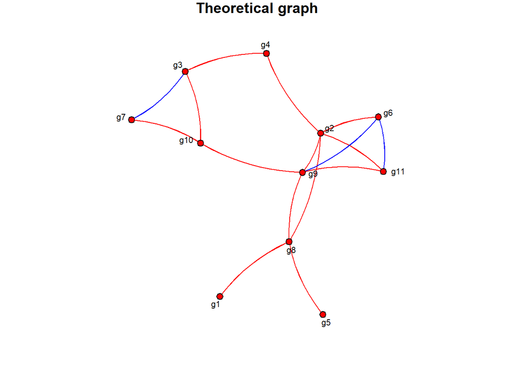

```r
plot(graphe)
```

```r
data <- rTranscriptData(n=1500, graphe, sigma=0)
```

```r
# Display the Sample
head(data$X)
```

```
##           g1         g2          g3         g4           g5         g6
## 1 -1.6166909 -1.5839797  2.02983317  0.2202606 -1.199402085 -0.7698566
## 2  2.1888756  1.2887958  2.37650366  0.5684360 -0.005703941 -1.0537361
## 3  1.3156013  1.4330767  0.26238022 -0.3697946  1.580161776  0.2277201
## 4  0.6827336 -1.8793593 -2.12553963 -0.3667555  0.271718177  0.7647731
## 5  2.2551746 -1.4116024 -0.77945921 -0.1480044 -0.706231447 -0.0639244
## 6 -1.0659654  0.9937526 -0.09718451  0.9283668 -0.936451539  1.5101216
##           g7         g8         g9        g10        g11
## 1  0.6252290 -0.9573505 -0.5114361 -0.1660802 -1.0974591
## 2 -0.7654529  1.5681021  2.4010002  1.4274294  1.4725906
## 3  1.7625641  0.8570342 -0.5297434  1.0038496 -0.5421239
## 4 -1.6575949  1.0285248  0.5938429  0.1433947  0.3328120
## 5  0.9458830 -0.4791508  0.3052772  0.6904118 -1.0165759
## 6 -1.4022189  0.2558606  0.2457645 -0.1109221  0.5430077
```

## 2.2 Inference of a conditional independence graph

```r
simone(data$X,control = setOptions(penalties=0.1)) -> infered_net
```

```
##
## Network Inference: neighborhood.selection with AND symmetrization rule applied
##
## |  penalty |    edges | criteria
##
##        0.1         16      -8048
```

```r
infered_net_graph <- getNetwork(infered_net)
```

```
##
## Found a network with 16 edges.
```

```r
infered_net_graph$name <- "Inferred graph"
```

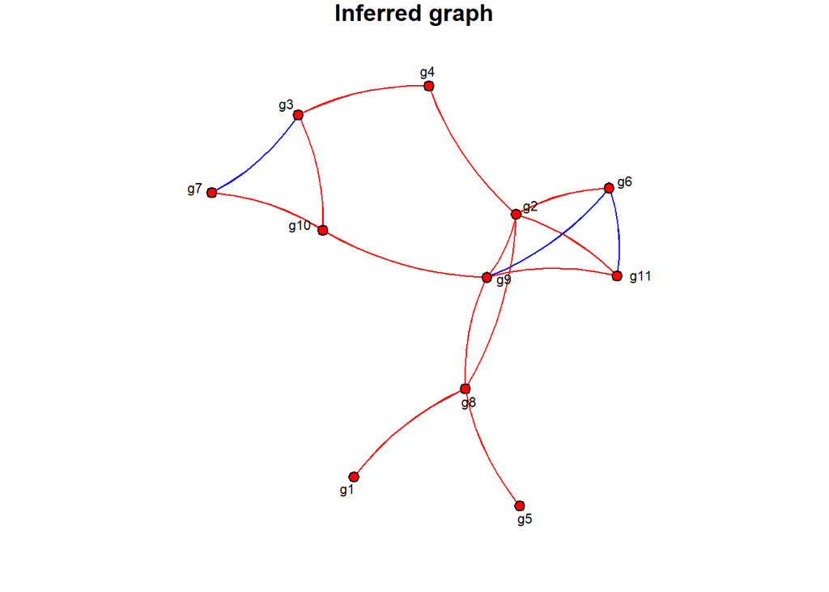

```r
plot(infered_net_graph)
```

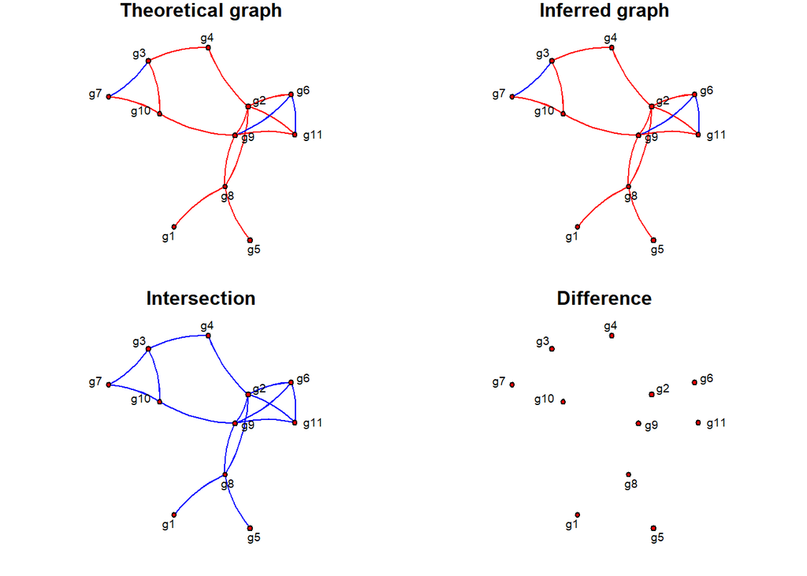

```r
## Let us compare the two networks
plot(graphe,infered_net_graph)
```

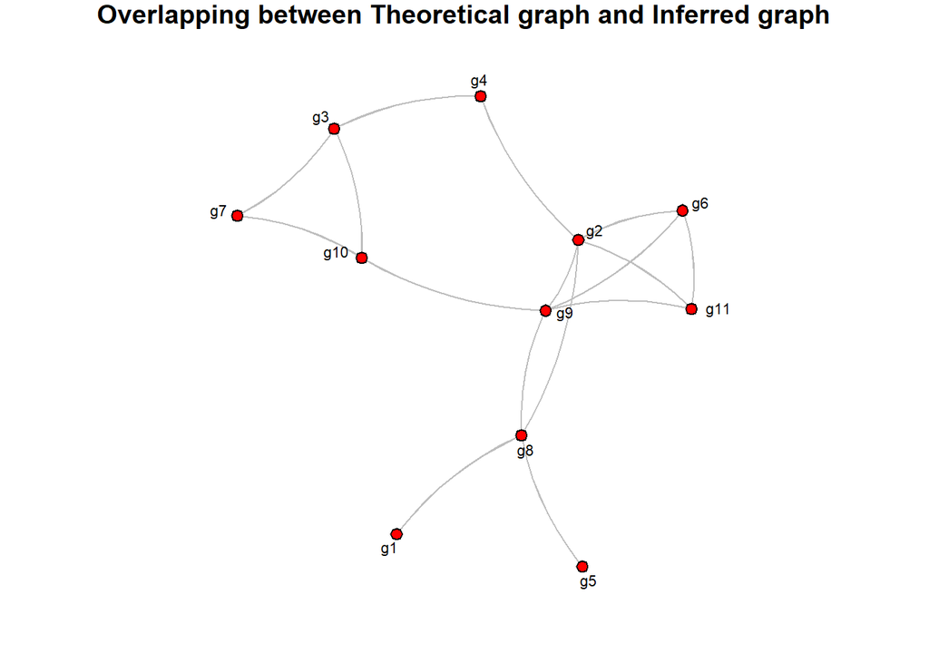

```r
plot(graphe,infered_net_graph, type="overlap")
```

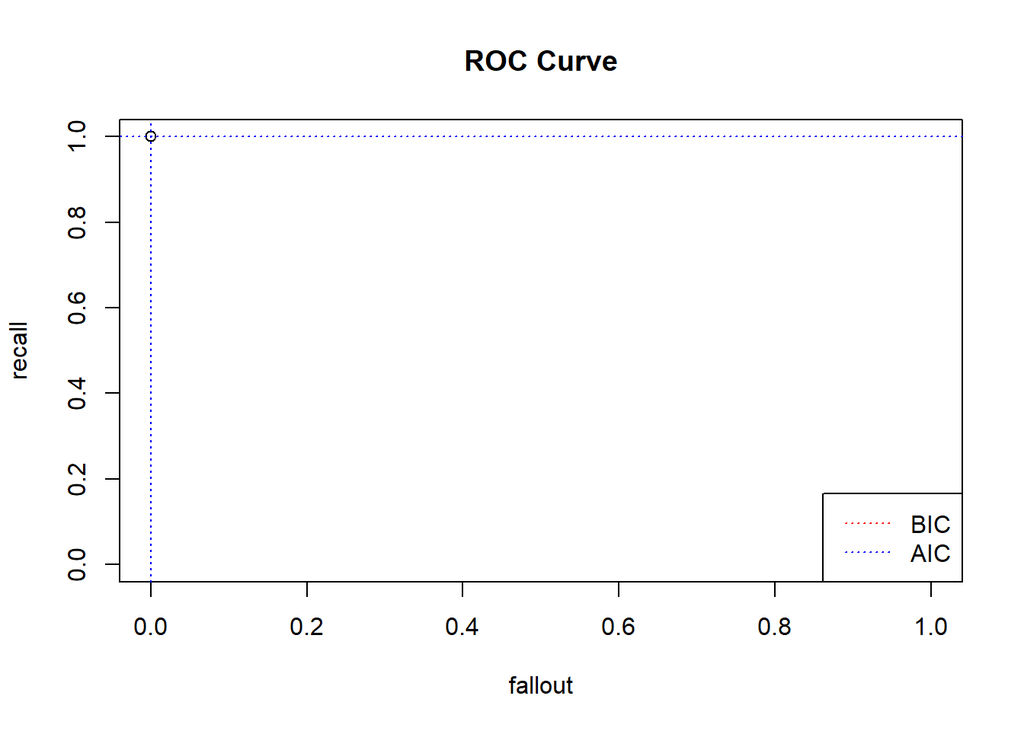

```
##
## Press return for next plot...
```

```r
plot(infered_net, output=c("ROC"), ref.graph=graphe$A)
```

**Comments:**

In terms of common edges, the inferred graph and the theoretical graph have no difference.

## 2.3 Precision-recall curve for 100 different penalties

```r
simone(data$X,control=setOptions(n.penalties = 100)) -> infered_net_100
```

```
##
## Network Inference: neighborhood.selection with AND symmetrization rule applied
##
## |  penalty |    edges | criteria
##
##          1          0     -23698
##     0.3737          1     -18528
##     0.3434          2     -18030
##     0.3333          3     -17824
##     0.3232          4     -17545
##      0.303          5     -16931
##     0.2727          6     -15899
##     0.2525          7     -15173
##     0.2424          8     -14731
##     0.2323         11     -14259
##     0.2121         13     -13248
##      0.202         14     -12737
##     0.1818         15     -11735
##     0.1111         16      -8551
##    0.04041         17      -5551
##    0.02021         26      -4721
##    0.01011         39      -4294
##      1e-05         55      -3752
```

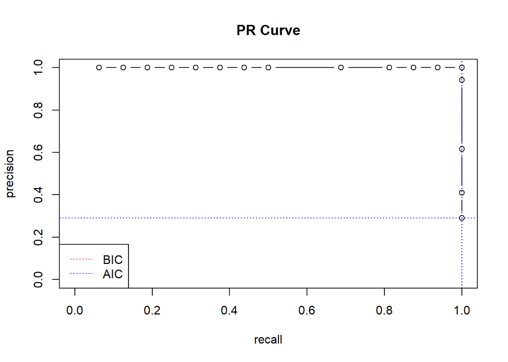

```
##
## Press return for next plot...
```

```r
plot(infered_net_100, output=c("PR"), ref.graph=graphe$A)
```

## 2.4 Inference and display of conditional independence networks

```r
PATH <- getwd()
```

```r
setwd(dir = PATH)
```

```r
# Load data
dataset <- read.table(file.choose(), header = FALSE, sep= "", encoding="UTF-8")
```

```r
# Display the Sample
head(dataset)
```

| V1 | V2 | V3 | V4 | V5 | V6 | V7 | V8 | V9 | V10 | V11 |
| --- | --- | --- | --- | --- | --- | --- | --- | --- | --- | --- |
| -97.67193 | -132.18100 | -46.03364 | -132.8207 | 31.765040 | -20.021190 | -64.16721 | -211.75860 | -13.34166 | -90.1145 | -33.267500 |
| -88.17193 | -128.88100 | -42.55364 | -134.3207 | -18.904960 | -8.031193 | -48.66721 | -273.75860 | -26.97166 | -118.5145 | -11.767500 |
| -64.67193 | -101.28100 | -40.25364 | -140.9207 | -14.034960 | -11.731190 | -48.66721 | -222.75860 | -18.94166 | -103.1145 | -53.767500 |
| -51.07193 | -62.58096 | -31.75364 | -137.6207 | -25.744960 | -20.801190 | -69.36721 | -97.75859 | -16.64166 | -106.4145 | -50.167500 |
| -90.37193 | -125.58100 | -49.66364 | -141.3907 | -2.234962 | -5.531193 | -35.06721 | -320.75860 | -25.68166 | -109.3145 | 8.032497 |
| -105.27190 | -141.63100 | -37.25364 | -129.0207 | -16.134960 | -14.731190 | -55.46721 | -15.75859 | -16.64166 | -85.9145 | -15.467500 |

```r
simone(dataset,control=setOptions(penalties=0.2)) -> infered_net_0.2
```

```
##
## Network Inference: neighborhood.selection with AND symmetrization rule applied
##
## |  penalty |    edges | criteria
##
##        0.2          7     -30732
```

```r
simone(dataset,control=setOptions(penalties=0.1)) -> infered_net_0.1
```

```
##
## Network Inference: neighborhood.selection with AND symmetrization rule applied
##
## |  penalty |    edges | criteria
##
##        0.1          9     -17115
```

```r
infered_net_0.2 <- getNetwork(infered_net_0.2)
```

```
##
## Found a network with 7 edges.
```

```r
infered_net_0.2$name <- "Inferred graph with penalties=0.2"
```

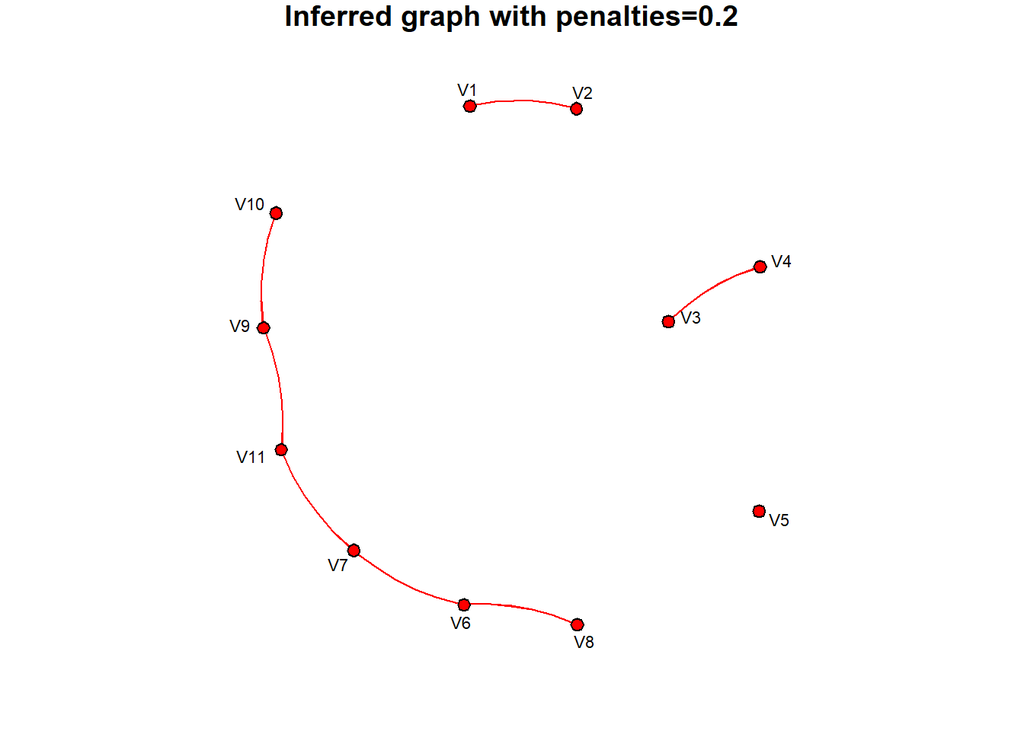

```r
plot(infered_net_0.2)
```

```r
infered_net_0.1 <- getNetwork(infered_net_0.1)
```

```
##
## Found a network with 9 edges.
```

```r
infered_net_0.1$name <- "Inferred graph with penalties=0.1"
```

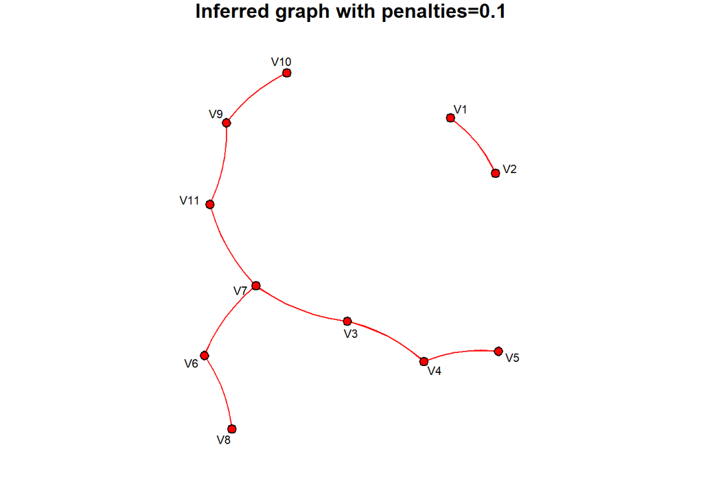

```r
plot(infered_net_0.1)
```

## 2.5 Discussion of results

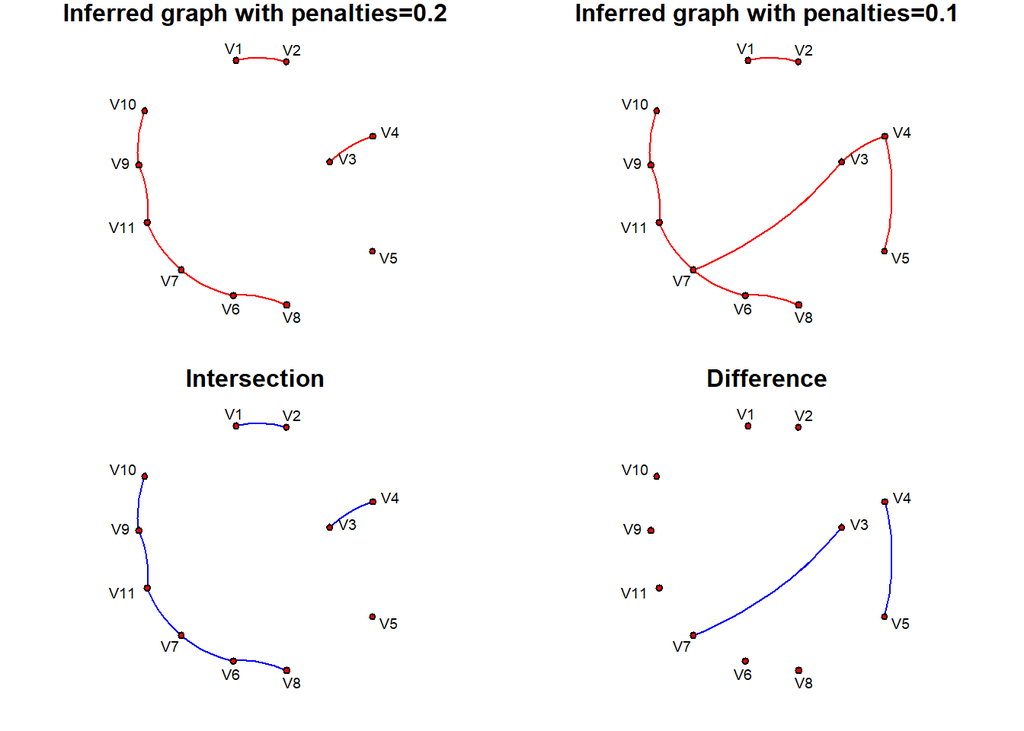

```r
## Let us compare the two networks
plot(infered_net_0.2,infered_net_0.1)
```

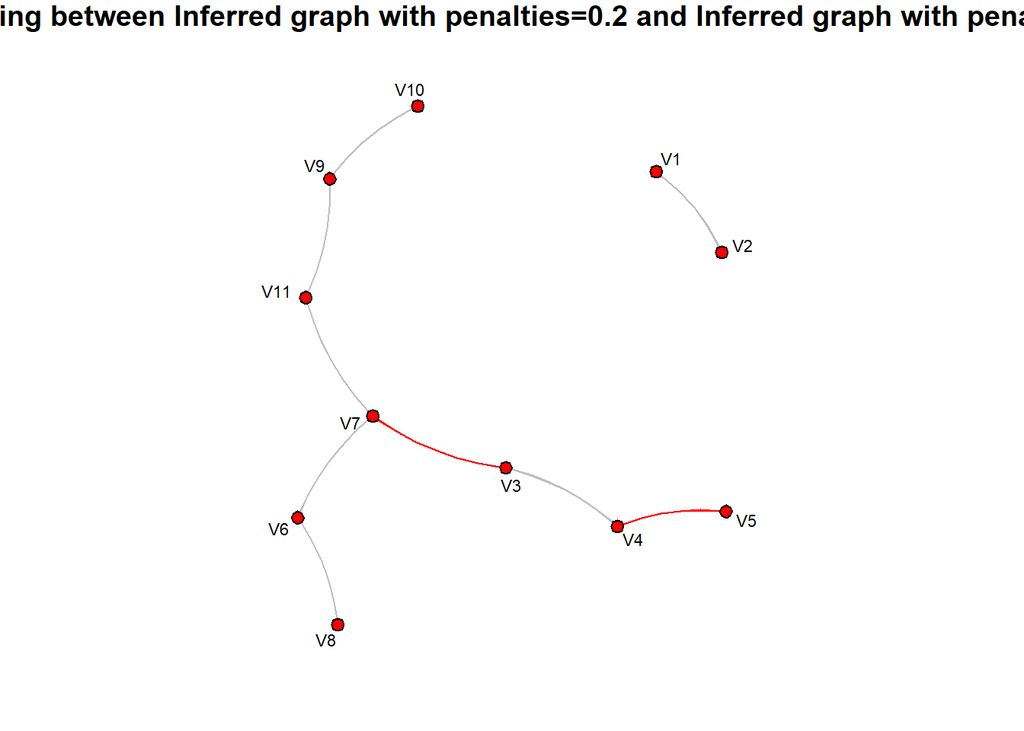

```r
plot(infered_net_0.2,infered_net_0.1, type="overlap")
```

The inferred network with a penalty of 0.2 has seven edges while the inferred network with a penalty of 0.1 has nine edges.